# PANNEURO_analysis

Christopher Huebel, Alish Palmos, Molly Davies, and Laura Hegemann

Sys.Date()

Frequencies of neurological symptoms in participants of the COPING/RAMP studies

Filtered by participants that self-reported a swap or antibody test

and that answered the neurological questionnaire

Script written by C Huebel Email: christopher.1.huebel@kcl.ac.uk

#Set up

Clear global environment

Retrieve the current date to use it for file endings to not overwrite files when one exports files

#Packages Install packages (if they are not available in your version of R)

Load packages

# Colour palettes

Define colours for plotting this are the standard coping colours

Choose in this chunk which palette to use 04.07.2020 - Default to 2 colour COPING palette

# ggplot theme

Set up ggplot theme for the plots

# Data import

## Source data file paths

## Read in data

## COVID swab test positive

| respiratory.throat_swab_test_nose | Sample | n | Prop |
| --- | --- | --- | --- |
| Positive | EDGI | 1 | 0.00 |
| Positive | GLAD | 60 | 0.00 |
| Positive | NBR | 46 | 0.00 |
| Positive | RAMP | 10 | 0.00 |
| Negative | EDGI | 9 | 0.00 |
| Negative | GLAD | 367 | 0.01 |
| Negative | NBR | 122 | 0.00 |
| Negative | RAMP | 30 | 0.00 |
| Result awaited | EDGI | 2 | 0.00 |
| Result awaited | GLAD | 81 | 0.00 |

[output cut: 6 more lines]

## antibody test

| respiratory.results_antibody_test | Sample | n | Prop |
| --- | --- | --- | --- |
| Positive | EDGI | 1 | 0.00 |
| Positive | GLAD | 14 | 0.00 |
| Positive | NBR | 7 | 0.00 |
| Positive | RAMP | 2 | 0.00 |
| Negative | EDGI | 4 | 0.00 |
| Negative | GLAD | 30 | 0.00 |
| Negative | NBR | 12 | 0.00 |
| Negative | RAMP | 2 | 0.00 |
| Result awaited | GLAD | 18 | 0.00 |
| Result awaited | NBR | 5 | 0.00 |

[output cut: 5 more lines]

## COVID positive test (antibody or swab)

| covid_test_positive | n |
| --- | --- |
| 0 | 22 |
| 1 | 132 |
| NA | 65069 |

## COVID probable diagnosis

| covid_probable_case_incl_screening | Sample | n | Prop |
| --- | --- | --- | --- |
| No COVID | EDGI | 460 | 0.01 |
| No COVID | GLAD | 10710 | 0.16 |
| No COVID | NBR | 12015 | 0.18 |
| No COVID | RAMP | 8307 | 0.13 |
| Probable COVID | EDGI | 45 | 0.00 |
| Probable COVID | GLAD | 1162 | 0.02 |
| Probable COVID | NBR | 609 | 0.01 |
| Probable COVID | RAMP | 187 | 0.00 |
| NA | EDGI | 1681 | 0.03 |
| NA | GLAD | 27198 | 0.42 |

[output cut: 2 more lines]

| covid_probable_case_incl_screening | n |
| --- | --- |
| No COVID | 31492 |
| Probable COVID | 2003 |
| NA | 31728 |

## Cross table probable covid and covid test positive

| covid_probable_case_incl_screening | 0 | 1 | <NA> |
| --- | --- | --- | --- |
| No COVID | 13 | 37 | 31442 |
| Probable COVID | 6 | 88 | 1909 |
| NA | 3 | 7 | 31718 |

# Demographics

## Age

### Proportion tables

| age_category | covid_probable_case_incl_screening | n | Prop |
| --- | --- | --- | --- |
| 16-18 | No COVID | 1023 | 0.02 |
| 16-18 | Probable COVID | 49 | 0.00 |
| 19-25 | No COVID | 2455 | 0.04 |
| 19-25 | Probable COVID | 204 | 0.00 |
| 26-35 | No COVID | 4574 | 0.07 |
| 26-35 | Probable COVID | 370 | 0.01 |
| 36-45 | No COVID | 4202 | 0.06 |
| 36-45 | Probable COVID | 397 | 0.01 |
| 46-55 | No COVID | 6274 | 0.10 |
| 46-55 | Probable COVID | 431 | 0.01 |
| 56-65 | No COVID | 7387 | 0.11 |
| 56-65 | Probable COVID | 400 | 0.01 |
| 66-70 | No COVID | 3027 | 0.05 |
| 66-70 | Probable COVID | 93 | 0.00 |
| 71-75 | No COVID | 1899 | 0.03 |
| 71-75 | Probable COVID | 45 | 0.00 |
| 76-80 | No COVID | 513 | 0.01 |
| 76-80 | Probable COVID | 11 | 0.00 |
| 81-85 | No COVID | 103 | 0.00 |
| 81-85 | Probable COVID | 2 | 0.00 |
| 86-90 | No COVID | 25 | 0.00 |
| 86-90 | Probable COVID | 1 | 0.00 |
| 91-100 | No COVID | 5 | 0.00 |
| 100+ | No COVID | 5 | 0.00 |

| age_category | covid_probable_case_incl_screening | n | Prop |
| --- | --- | --- | --- |
| 16-18 | No COVID | 1023 | 0.02 |
| 16-18 | Probable COVID | 49 | 0.00 |
| 19-25 | No COVID | 2455 | 0.04 |
| 19-25 | Probable COVID | 204 | 0.00 |
| 26-35 | No COVID | 4574 | 0.07 |
| 26-35 | Probable COVID | 370 | 0.01 |
| 36-45 | No COVID | 4202 | 0.06 |
| 36-45 | Probable COVID | 397 | 0.01 |
| 46-55 | No COVID | 6274 | 0.10 |
| 46-55 | Probable COVID | 431 | 0.01 |

[output cut: 14 more lines]

| covid_probable_case_incl_screening | age_category | n | Prop |
| --- | --- | --- | --- |
| No COVID | 16-18 | 1023 | 0.03 |
| No COVID | 19-25 | 2455 | 0.08 |
| No COVID | 26-35 | 4574 | 0.15 |
| No COVID | 36-45 | 4202 | 0.13 |
| No COVID | 46-55 | 6274 | 0.20 |
| No COVID | 56-65 | 7387 | 0.23 |
| No COVID | 66-70 | 3027 | 0.10 |
| No COVID | 71-75 | 1899 | 0.06 |
| No COVID | 76-80 | 513 | 0.02 |
| No COVID | 81-85 | 103 | 0.00 |
| No COVID | 86-90 | 25 | 0.00 |
| No COVID | 91-100 | 5 | 0.00 |
| No COVID | 100+ | 5 | 0.00 |
| Probable COVID | 16-18 | 49 | 0.02 |
| Probable COVID | 19-25 | 204 | 0.10 |
| Probable COVID | 26-35 | 370 | 0.18 |
| Probable COVID | 36-45 | 397 | 0.20 |
| Probable COVID | 46-55 | 431 | 0.22 |
| Probable COVID | 56-65 | 400 | 0.20 |
| Probable COVID | 66-70 | 93 | 0.05 |
| Probable COVID | 71-75 | 45 | 0.02 |
| Probable COVID | 76-80 | 11 | 0.01 |
| Probable COVID | 81-85 | 2 | 0.00 |
| Probable COVID | 86-90 | 1 | 0.00 |

| covid_probable_case_incl_screening | age_category | n | Prop |
| --- | --- | --- | --- |
| No COVID | 16-18 | 1023 | 0.03 |
| No COVID | 19-25 | 2455 | 0.08 |
| No COVID | 26-35 | 4574 | 0.15 |
| No COVID | 36-45 | 4202 | 0.13 |
| No COVID | 46-55 | 6274 | 0.20 |
| No COVID | 56-65 | 7387 | 0.23 |
| No COVID | 66-70 | 3027 | 0.10 |
| No COVID | 71-75 | 1899 | 0.06 |
| No COVID | 76-80 | 513 | 0.02 |
| No COVID | 81-85 | 103 | 0.00 |

[output cut: 14 more lines]

### Cross tables

| age_category | n_No COVID | n_Probable COVID | Prop_No COVID | Prop_Probable COVID |
| --- | --- | --- | --- | --- |
| 16-18 | 1023 | 49 | 0.03 | 0.02 |
| 19-25 | 2455 | 204 | 0.08 | 0.10 |
| 26-35 | 4574 | 370 | 0.15 | 0.18 |
| 36-45 | 4202 | 397 | 0.13 | 0.20 |
| 46-55 | 6274 | 431 | 0.20 | 0.22 |
| 56-65 | 7387 | 400 | 0.23 | 0.20 |
| 66-70 | 3027 | 93 | 0.10 | 0.05 |
| 71-75 | 1899 | 45 | 0.06 | 0.02 |
| 76-80 | 513 | 11 | 0.02 | 0.01 |
| 81-85 | 103 | 2 | 0.00 | 0.00 |
| 86-90 | 25 | 1 | 0.00 | 0.00 |
| 91-100 | 5 | NA | 0.00 | NA |
| 100+ | 5 | NA | 0.00 | NA |

| age_category | n_No COVID | n_Probable COVID | Prop_No COVID | Prop_Probable COVID |
| --- | --- | --- | --- | --- |
| 16-18 | 1023 | 49 | 0.03 | 0.02 |
| 19-25 | 2455 | 204 | 0.08 | 0.10 |
| 26-35 | 4574 | 370 | 0.15 | 0.18 |
| 36-45 | 4202 | 397 | 0.13 | 0.20 |
| 46-55 | 6274 | 431 | 0.20 | 0.22 |
| 56-65 | 7387 | 400 | 0.23 | 0.20 |
| 66-70 | 3027 | 93 | 0.10 | 0.05 |
| 71-75 | 1899 | 45 | 0.06 | 0.02 |
| 76-80 | 513 | 11 | 0.02 | 0.01 |
| 81-85 | 103 | 2 | 0.00 | 0.00 |

[output cut: 3 more lines]

### Collapse age categories

```
Frequencies
dat.raw$age_category_collapsed
Type: Factor

               Freq   % Valid   % Valid Cum.   % Total   % Total Cum.
----------- ------- --------- -------------- --------- --------------
      16-18    3117      4.78           4.78      4.78           4.78
      19-25    9322     14.29          19.07     14.29          19.07
      26-35   13254     20.32          39.39     20.32          39.39
      36-45   10147     15.56          54.95     15.56          54.95
      46-55   11759     18.03          72.98     18.03          72.98
      56-65   10695     16.40          89.38     16.40          89.38
      66-70    3788      5.81          95.18      5.81          95.18
      71-75    2342      3.59          98.77      3.59          98.77
        76+     799      1.23         100.00      1.23         100.00
       <NA>       0                               0.00         100.00
      Total   65223    100.00         100.00    100.00         100.00
```

### Proportion tables

| age_category_collapsed | covid_probable_case_incl_screening | n | Prop |
| --- | --- | --- | --- |
| 16-18 | No COVID | 1023 | 0.02 |
| 16-18 | Probable COVID | 49 | 0.00 |
| 19-25 | No COVID | 2455 | 0.04 |
| 19-25 | Probable COVID | 204 | 0.00 |
| 26-35 | No COVID | 4574 | 0.07 |
| 26-35 | Probable COVID | 370 | 0.01 |
| 36-45 | No COVID | 4202 | 0.06 |
| 36-45 | Probable COVID | 397 | 0.01 |
| 46-55 | No COVID | 6274 | 0.10 |
| 46-55 | Probable COVID | 431 | 0.01 |
| 56-65 | No COVID | 7387 | 0.11 |
| 56-65 | Probable COVID | 400 | 0.01 |
| 66-70 | No COVID | 3027 | 0.05 |
| 66-70 | Probable COVID | 93 | 0.00 |
| 71-75 | No COVID | 1899 | 0.03 |
| 71-75 | Probable COVID | 45 | 0.00 |
| 76+ | No COVID | 651 | 0.01 |
| 76+ | Probable COVID | 14 | 0.00 |

| age_category_collapsed | covid_probable_case_incl_screening | n | Prop |
| --- | --- | --- | --- |
| 16-18 | No COVID | 1023 | 0.02 |
| 16-18 | Probable COVID | 49 | 0.00 |
| 19-25 | No COVID | 2455 | 0.04 |
| 19-25 | Probable COVID | 204 | 0.00 |
| 26-35 | No COVID | 4574 | 0.07 |
| 26-35 | Probable COVID | 370 | 0.01 |
| 36-45 | No COVID | 4202 | 0.06 |
| 36-45 | Probable COVID | 397 | 0.01 |
| 46-55 | No COVID | 6274 | 0.10 |
| 46-55 | Probable COVID | 431 | 0.01 |

[output cut: 8 more lines]

| covid_probable_case_incl_screening | age_category_collapsed | n | Prop |
| --- | --- | --- | --- |
| No COVID | 16-18 | 1023 | 0.03 |
| No COVID | 19-25 | 2455 | 0.08 |
| No COVID | 26-35 | 4574 | 0.15 |
| No COVID | 36-45 | 4202 | 0.13 |
| No COVID | 46-55 | 6274 | 0.20 |
| No COVID | 56-65 | 7387 | 0.23 |
| No COVID | 66-70 | 3027 | 0.10 |
| No COVID | 71-75 | 1899 | 0.06 |
| No COVID | 76+ | 651 | 0.02 |
| Probable COVID | 16-18 | 49 | 0.02 |
| Probable COVID | 19-25 | 204 | 0.10 |
| Probable COVID | 26-35 | 370 | 0.18 |
| Probable COVID | 36-45 | 397 | 0.20 |
| Probable COVID | 46-55 | 431 | 0.22 |
| Probable COVID | 56-65 | 400 | 0.20 |
| Probable COVID | 66-70 | 93 | 0.05 |
| Probable COVID | 71-75 | 45 | 0.02 |
| Probable COVID | 76+ | 14 | 0.01 |

| covid_probable_case_incl_screening | age_category_collapsed | n | Prop |
| --- | --- | --- | --- |
| No COVID | 16-18 | 1023 | 0.03 |
| No COVID | 19-25 | 2455 | 0.08 |
| No COVID | 26-35 | 4574 | 0.15 |
| No COVID | 36-45 | 4202 | 0.13 |
| No COVID | 46-55 | 6274 | 0.20 |
| No COVID | 56-65 | 7387 | 0.23 |
| No COVID | 66-70 | 3027 | 0.10 |
| No COVID | 71-75 | 1899 | 0.06 |
| No COVID | 76+ | 651 | 0.02 |
| Probable COVID | 16-18 | 49 | 0.02 |

[output cut: 8 more lines]

### Cross tables

| age_category_collapsed | n_No COVID | n_Probable COVID | Prop_No COVID | Prop_Probable COVID |
| --- | --- | --- | --- | --- |
| 16-18 | 1023 | 49 | 0.03 | 0.02 |
| 19-25 | 2455 | 204 | 0.08 | 0.10 |
| 26-35 | 4574 | 370 | 0.15 | 0.18 |
| 36-45 | 4202 | 397 | 0.13 | 0.20 |
| 46-55 | 6274 | 431 | 0.20 | 0.22 |
| 56-65 | 7387 | 400 | 0.23 | 0.20 |
| 66-70 | 3027 | 93 | 0.10 | 0.05 |
| 71-75 | 1899 | 45 | 0.06 | 0.02 |
| 76+ | 651 | 14 | 0.02 | 0.01 |

| age_category_collapsed | n_No COVID | n_Probable COVID | Prop_No COVID | Prop_Probable COVID |
| --- | --- | --- | --- | --- |
| 16-18 | 1023 | 49 | 0.03 | 0.02 |
| 19-25 | 2455 | 204 | 0.08 | 0.10 |
| 26-35 | 4574 | 370 | 0.15 | 0.18 |
| 36-45 | 4202 | 397 | 0.13 | 0.20 |
| 46-55 | 6274 | 431 | 0.20 | 0.22 |
| 56-65 | 7387 | 400 | 0.23 | 0.20 |
| 66-70 | 3027 | 93 | 0.10 | 0.05 |
| 71-75 | 1899 | 45 | 0.06 | 0.02 |
| 76+ | 651 | 14 | 0.02 | 0.01 |

### Chi square test

| statistic | p.value | parameter | method |
| --- | --- | --- | --- |
| 221.1199 | 0 | 8 | Pearson’s Chi-squared test |

| statistic | p.value | parameter | method |
| --- | --- | --- | --- |
| 221.1199 | 2.233036e-43 | 8 | Pearson's Chi-squared test |

## Sex

| Sex | covid_probable_case_incl_screening | n | Prop |
| --- | --- | --- | --- |
| Male | No COVID | 7227 | 0.29 |
| Male | Probable COVID | 408 | 0.02 |
| Female | No COVID | 15958 | 0.64 |
| Female | Probable COVID | 1408 | 0.06 |

| Sex | covid_probable_case_incl_screening | n | Prop |
| --- | --- | --- | --- |
| Male | No COVID | 7227 | 0.29 |
| Male | Probable COVID | 408 | 0.02 |
| Female | No COVID | 15958 | 0.64 |
| Female | Probable COVID | 1408 | 0.06 |

## Smoking not available

## BMI not available

## Key worker status

| key_worker | covid_probable_case_incl_screening | n | Prop |
| --- | --- | --- | --- |
| No key worker | No COVID | 20207 | 0.61 |
| No key worker | Probable COVID | 1033 | 0.03 |
| Key worker | No COVID | 11191 | 0.34 |
| Key worker | Probable COVID | 959 | 0.03 |

| key_worker | covid_probable_case_incl_screening | n | Prop |
| --- | --- | --- | --- |
| No key worker | No COVID | 20207 | 0.61 |
| No key worker | Probable COVID | 1033 | 0.03 |
| Key worker | No COVID | 11191 | 0.34 |
| Key worker | Probable COVID | 959 | 0.03 |

## Smoking

## BMI

## Key worker status

## Ethnicity_collapsed

```
Frequencies
dat.raw$Ethnicity_collapsed
Type: Factor

                                          Freq   % Valid   % Valid Cum.   % Total   % Total Cum.
-------------------------------------- ------- --------- -------------- --------- --------------
                              European   58435     94.83          94.83     89.59          89.59
      Mixed or multiple ethnic origins    1383      2.24          97.07      2.12          91.71
                Asian or Asian British     934      1.52          98.58      1.43          93.15
            African or African British     390      0.63          99.22      0.60          93.74
                                 Other     482      0.78         100.00      0.74          94.48
                                  <NA>    3599                               5.52         100.00
                                 Total   65223    100.00         100.00    100.00         100.00
```

| covid_probable_case_incl_screening | Ethnicity_collapsed | n | freq |
| --- | --- | --- | --- |
| No COVID | European | 27611 | 0.90 |
| No COVID | Mixed or multiple ethnic origins | 509 | 0.02 |
| No COVID | Asian or Asian British | 364 | 0.01 |
| No COVID | African or African British | 159 | 0.01 |
| No COVID | Other | 157 | 0.01 |
| Probable COVID | European | 1761 | 0.06 |
| Probable COVID | Mixed or multiple ethnic origins | 40 | 0.00 |
| Probable COVID | Asian or Asian British | 17 | 0.00 |
| Probable COVID | African or African British | 18 | 0.00 |
| Probable COVID | Other | 17 | 0.00 |

| covid_probable_case_incl_screening | Ethnicity_collapsed | n | freq |
| --- | --- | --- | --- |
| No COVID | European | 27611 | 0.90 |
| No COVID | Mixed or multiple ethnic origins | 509 | 0.02 |
| No COVID | Asian or Asian British | 364 | 0.01 |
| No COVID | African or African British | 159 | 0.01 |
| No COVID | Other | 157 | 0.01 |
| Probable COVID | European | 1761 | 0.06 |
| Probable COVID | Mixed or multiple ethnic origins | 40 | 0.00 |
| Probable COVID | Asian or Asian British | 17 | 0.00 |
| Probable COVID | African or African British | 18 | 0.00 |
| Probable COVID | Other | 17 | 0.00 |

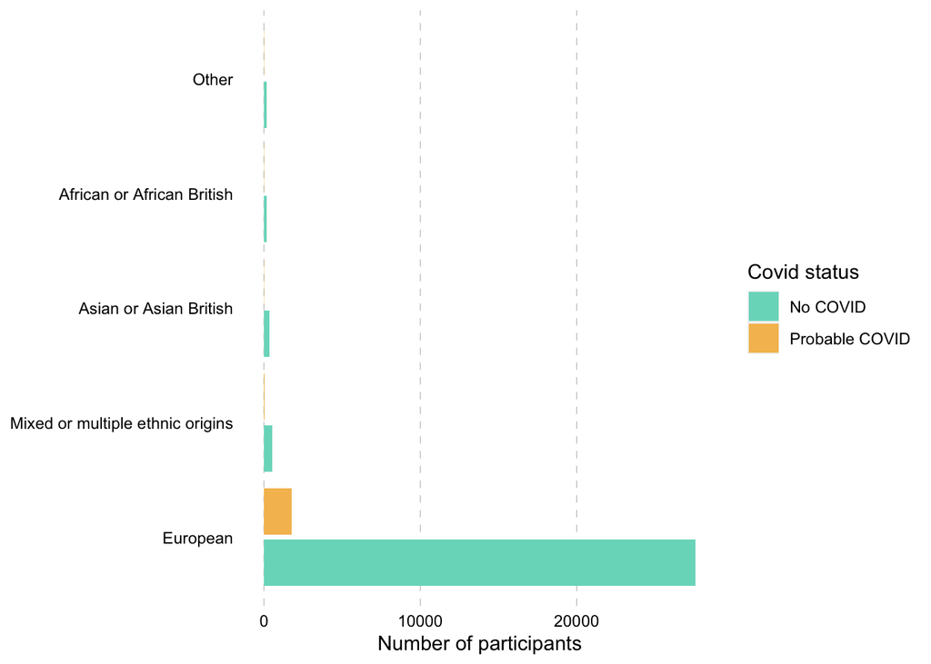

###Chi-square

| statistic | p.value | parameter | method |
| --- | --- | --- | --- |
| 15.70198 | 0.0077485 | 5 | Pearson’s Chi-squared test |

| statistic | p.value | parameter | method |
| --- | --- | --- | --- |
| 15.70198 | 0.007748507 | 5 | Pearson's Chi-squared test |

# Neurological frequencies

```
[1] "covid_probable_case_incl_screening"
[2] "alsfrs.limb_weakness_noticed_past"
[3] "alsfrs.normal"
[4] "alsfrs.slow_or_sloppy_all_words_are_legible"
[5] "alsfrs.not_all_words_are_legible"
[6] "alsfrs.able_to_grip_pen"
[7] "alsfrs.unable_to_grip_pen"
[8] "alsfrs.have_you_noticed_any_difficulty_walking"
[9] "alsfrs.do_you_have_any_difficulty_climbing_stairs"
```

alsfrs.limb_weakness_noticed_past, alsfrs.normal, alsfrs.slow_or_sloppy_all_words_are_legible, alsfrs.not_all_words_are_legible, alsfrs.able_to_grip_pen, alsfrs.unable_to_grip_pen, alsfrs.have_you_noticed_any_difficulty_walking, alsfrs.do_you_have_any_difficulty_climbing_stairs

| covid_probable_case_incl_screening | alsfrs.limb_weakness_noticed_past | n | Prop |
| --- | --- | --- | --- |
| No COVID | No | 18396 | 0.86 |
| No COVID | Yes | 2277 | 0.11 |
| Probable COVID | No | 620 | 0.03 |
| Probable COVID | Yes | 218 | 0.01 |

| covid_probable_case_incl_screening | alsfrs.normal | n | Prop |
| --- | --- | --- | --- |
| No COVID | Not Normal | 579 | 0.25 |
| No COVID | Normal | 1704 | 0.75 |
| Probable COVID | Not Normal | 80 | 0.37 |
| Probable COVID | Normal | 138 | 0.63 |

| covid_probable_case_incl_screening | alsfrs.slow_or_sloppy_all_words_are_legible | n | Prop |
| --- | --- | --- | --- |
| No COVID | Not Slow or sloppy, all words are legible | 2011 | 0.88 |
| No COVID | Slow or sloppy, all words are legible | 272 | 0.12 |
| Probable COVID | Not Slow or sloppy, all words are legible | 183 | 0.84 |
| Probable COVID | Slow or sloppy, all words are legible | 35 | 0.16 |

| covid_probable_case_incl_screening | alsfrs.not_all_words_are_legible | n | Prop |
| --- | --- | --- | --- |
| No COVID | Not Not all words are legible | 2093 | 0.92 |
| No COVID | Not all words are legible | 190 | 0.08 |
| Probable COVID | Not Not all words are legible | 191 | 0.88 |
| Probable COVID | Not all words are legible | 27 | 0.12 |

| covid_probable_case_incl_screening | alsfrs.able_to_grip_pen | n | Prop |
| --- | --- | --- | --- |
| No COVID | Not Able to grip pen | 2208 | 0.97 |
| No COVID | Able to grip pen | 75 | 0.03 |
| Probable COVID | Not Able to grip pen | 207 | 0.95 |
| Probable COVID | Able to grip pen | 11 | 0.05 |

| covid_probable_case_incl_screening | alsfrs.unable_to_grip_pen | n | Prop |
| --- | --- | --- | --- |
| No COVID | Not Unable to grip pen | 2176 | 0.95 |
| No COVID | Unable to grip pen | 107 | 0.05 |
| Probable COVID | Not Unable to grip pen | 199 | 0.91 |
| Probable COVID | Unable to grip pen | 19 | 0.09 |

| covid_probable_case_incl_screening | alsfrs.have_you_noticed_any_difficulty_walking | n | Prop |
| --- | --- | --- | --- |
| No COVID | Normal | 1310 | 0.57 |
| No COVID | Early walking difficultly | 710 | 0.31 |
| No COVID | Need a person, crutch or frame to help you walk | 232 | 0.10 |
| No COVID | Able to stand for transfers | 14 | 0.01 |
| No COVID | No purposeful leg movement | 14 | 0.01 |
| No COVID | N/A | 2 | 0.00 |
| Probable COVID | Normal | 119 | 0.55 |
| Probable COVID | Early walking difficultly | 75 | 0.34 |
| Probable COVID | Need a person, crutch or frame to help you walk | 23 | 0.11 |
| Probable COVID | Able to stand for transfers | 1 | 0.00 |

| covid_probable_case_incl_screening | alsfrs.do_you_have_any_difficulty_climbing_stairs | n | Prop |
| --- | --- | --- | --- |
| No COVID | Normal | 1171 | 0.51 |
| No COVID | Slow | 515 | 0.23 |
| No COVID | Mild unsteadiness or fatigue | 343 | 0.15 |
| No COVID | Need assistance of a person or a rail | 183 | 0.08 |
| No COVID | Cannot climb stairs | 73 | 0.03 |
| Probable COVID | Normal | 93 | 0.42 |
| Probable COVID | Slow | 46 | 0.21 |
| Probable COVID | Mild unsteadiness or fatigue | 55 | 0.25 |
| Probable COVID | Need assistance of a person or a rail | 12 | 0.05 |
| Probable COVID | Cannot climb stairs | 13 | 0.06 |

```
 [1] "covid_probable_case_incl_screening"
 [2] "ess.felt_excessively_sleepy_past"
 [3] "ess.sitting_and_reading"
 [4] "ess.watching_tv"
 [5] "ess.sitting_inactive_in_a_public_place"
 [6] "ess.break_passenger_car_hour"
 [7] "ess.afternoon_rest_circumstances_lying"
 [8] "ess.sitting_and_talking_to_someone"
 [9] "ess.sitting_quietly_after_a_lunch_without_alcohol"
[10] "ess.car_minutes_stopped_traffic"
[11] "ess.insomnia"
[12] "ess.narcolepsy"
[13] "ess.rem_sleep_behaviour_disorder"
[14] "ess.restless_legs_syndrome"
[15] "ess.sleep_apnea"
[16] "ess.sleep_terrors"
[17] "ess.sleepwalking"
[18] "ess.other"
[19] "ess.none"
```

| covid_probable_case_incl_screening | ess.felt_excessively_sleepy_past | n | Prop |
| --- | --- | --- | --- |
| No COVID | No | 14546 | 0.70 |
| No COVID | Yes | 6117 | 0.30 |
| Probable COVID | No | 427 | 0.51 |
| Probable COVID | Yes | 412 | 0.49 |

| covid_probable_case_incl_screening | ess.sitting_and_reading | n | Prop |
| --- | --- | --- | --- |
| No COVID | Would never doze | 1263 | 0.21 |
| No COVID | Slight chance of dozing | 2470 | 0.40 |
| No COVID | Moderate chance of dozing | 1563 | 0.26 |
| No COVID | High chance of dozing | 809 | 0.13 |
| Probable COVID | Would never doze | 66 | 0.16 |
| Probable COVID | Slight chance of dozing | 182 | 0.45 |
| Probable COVID | Moderate chance of dozing | 103 | 0.25 |
| Probable COVID | High chance of dozing | 57 | 0.14 |

| covid_probable_case_incl_screening | ess.watching_tv | n | Prop |
| --- | --- | --- | --- |
| No COVID | Would never doze | 997 | 0.16 |
| No COVID | Slight chance of dozing | 2386 | 0.39 |
| No COVID | Moderate chance of dozing | 1741 | 0.29 |
| No COVID | High chance of dozing | 973 | 0.16 |
| Probable COVID | Would never doze | 56 | 0.14 |
| Probable COVID | Slight chance of dozing | 166 | 0.41 |
| Probable COVID | Moderate chance of dozing | 133 | 0.33 |
| Probable COVID | High chance of dozing | 52 | 0.13 |

| covid_probable_case_incl_screening | ess.sitting_inactive_in_a_public_place | n | Prop |
| --- | --- | --- | --- |
| No COVID | Would never doze | 3871 | 0.64 |
| No COVID | Slight chance of dozing | 1530 | 0.25 |
| No COVID | Moderate chance of dozing | 492 | 0.08 |
| No COVID | High chance of dozing | 197 | 0.03 |
| Probable COVID | Would never doze | 237 | 0.58 |
| Probable COVID | Slight chance of dozing | 116 | 0.29 |
| Probable COVID | Moderate chance of dozing | 37 | 0.09 |
| Probable COVID | High chance of dozing | 17 | 0.04 |

| covid_probable_case_incl_screening | ess.break_passenger_car_hour | n | Prop |
| --- | --- | --- | --- |
| No COVID | Would never doze | 1955 | 0.32 |
| No COVID | Slight chance of dozing | 2177 | 0.36 |
| No COVID | Moderate chance of dozing | 1147 | 0.19 |
| No COVID | High chance of dozing | 812 | 0.13 |
| Probable COVID | Would never doze | 145 | 0.36 |
| Probable COVID | Slight chance of dozing | 135 | 0.33 |
| Probable COVID | Moderate chance of dozing | 70 | 0.17 |
| Probable COVID | High chance of dozing | 57 | 0.14 |

| covid_probable_case_incl_screening | ess.afternoon_rest_circumstances_lying | n | Prop |
| --- | --- | --- | --- |
| No COVID | Would never doze | 578 | 0.09 |
| No COVID | Slight chance of dozing | 1421 | 0.23 |
| No COVID | Moderate chance of dozing | 1724 | 0.28 |
| No COVID | High chance of dozing | 2381 | 0.39 |
| Probable COVID | Would never doze | 29 | 0.07 |
| Probable COVID | Slight chance of dozing | 113 | 0.28 |
| Probable COVID | Moderate chance of dozing | 111 | 0.27 |
| Probable COVID | High chance of dozing | 155 | 0.38 |

| covid_probable_case_incl_screening | ess.sitting_and_talking_to_someone | n | Prop |
| --- | --- | --- | --- |
| No COVID | Would never doze | 5377 | 0.88 |
| No COVID | Slight chance of dozing | 584 | 0.10 |
| No COVID | Moderate chance of dozing | 104 | 0.02 |
| No COVID | High chance of dozing | 42 | 0.01 |
| Probable COVID | Would never doze | 339 | 0.83 |
| Probable COVID | Slight chance of dozing | 50 | 0.12 |
| Probable COVID | Moderate chance of dozing | 17 | 0.04 |
| Probable COVID | High chance of dozing | 2 | 0.00 |

| covid_probable_case_incl_screening | ess.sitting_quietly_after_a_lunch_without_alcohol | n | Prop |
| --- | --- | --- | --- |
| No COVID | Would never doze | 2688 | 0.44 |
| No COVID | Slight chance of dozing | 2234 | 0.37 |
| No COVID | Moderate chance of dozing | 806 | 0.13 |
| No COVID | High chance of dozing | 372 | 0.06 |
| Probable COVID | Would never doze | 183 | 0.45 |
| Probable COVID | Slight chance of dozing | 137 | 0.34 |
| Probable COVID | Moderate chance of dozing | 60 | 0.15 |
| Probable COVID | High chance of dozing | 27 | 0.07 |

| covid_probable_case_incl_screening | ess.car_minutes_stopped_traffic | n | Prop |
| --- | --- | --- | --- |
| No COVID | Would never doze | 5426 | 0.89 |
| No COVID | Slight chance of dozing | 518 | 0.08 |
| No COVID | Moderate chance of dozing | 102 | 0.02 |
| No COVID | High chance of dozing | 52 | 0.01 |
| Probable COVID | Would never doze | 361 | 0.88 |
| Probable COVID | Slight chance of dozing | 30 | 0.07 |
| Probable COVID | Moderate chance of dozing | 10 | 0.02 |
| Probable COVID | High chance of dozing | 7 | 0.02 |

| covid_probable_case_incl_screening | ess.insomnia | n | Prop |
| --- | --- | --- | --- |
| No COVID | Insomnia | 259 | 0.02 |
| No COVID | Not Insomnia | 12153 | 0.98 |
| Probable COVID | Insomnia | 26 | 0.04 |
| Probable COVID | Not Insomnia | 625 | 0.96 |

| covid_probable_case_incl_screening | ess.narcolepsy | n | Prop |
| --- | --- | --- | --- |
| No COVID | Narcolepsy | 6 | 0 |
| No COVID | Not Narcolepsy | 12406 | 1 |
| Probable COVID | Narcolepsy | 1 | 0 |
| Probable COVID | Not Narcolepsy | 650 | 1 |

| covid_probable_case_incl_screening | ess.rem_sleep_behaviour_disorder | n | Prop |
| --- | --- | --- | --- |
| No COVID | Not REM sleep behaviour disorder | 12392 | 1 |
| No COVID | REM sleep behaviour disorder | 20 | 0 |
| Probable COVID | Not REM sleep behaviour disorder | 648 | 1 |
| Probable COVID | REM sleep behaviour disorder | 3 | 0 |

| covid_probable_case_incl_screening | ess.restless_legs_syndrome | n | Prop |
| --- | --- | --- | --- |
| No COVID | Not Restless legs syndrome | 12108 | 0.98 |
| No COVID | Restless legs syndrome | 304 | 0.02 |
| Probable COVID | Not Restless legs syndrome | 625 | 0.96 |
| Probable COVID | Restless legs syndrome | 26 | 0.04 |

| covid_probable_case_incl_screening | ess.sleep_apnea | n | Prop |
| --- | --- | --- | --- |
| No COVID | Not Sleep apnea | 12224 | 0.98 |
| No COVID | Sleep apnea | 188 | 0.02 |
| Probable COVID | Not Sleep apnea | 633 | 0.97 |
| Probable COVID | Sleep apnea | 18 | 0.03 |

| covid_probable_case_incl_screening | ess.sleep_terrors | n | Prop |
| --- | --- | --- | --- |
| No COVID | Not Sleep terrors | 12349 | 0.99 |
| No COVID | Sleep terrors | 63 | 0.01 |
| Probable COVID | Not Sleep terrors | 645 | 0.99 |
| Probable COVID | Sleep terrors | 6 | 0.01 |

| covid_probable_case_incl_screening | ess.sleepwalking | n | Prop |
| --- | --- | --- | --- |
| No COVID | Not Sleepwalking | 12381 | 1.00 |
| No COVID | Sleepwalking | 31 | 0.00 |
| Probable COVID | Not Sleepwalking | 644 | 0.99 |
| Probable COVID | Sleepwalking | 7 | 0.01 |

| covid_probable_case_incl_screening | ess.other | n | Prop |
| --- | --- | --- | --- |
| No COVID | Not Other: | 12293 | 0.99 |
| No COVID | Other: | 119 | 0.01 |
| Probable COVID | Not Other: | 636 | 0.98 |
| Probable COVID | Other: | 15 | 0.02 |

| covid_probable_case_incl_screening | ess.none | n | Prop |
| --- | --- | --- | --- |
| No COVID | None | 11555 | 0.93 |
| No COVID | Not None | 857 | 0.07 |
| Probable COVID | None | 571 | 0.88 |
| Probable COVID | Not None | 80 | 0.12 |

```
[1] "covid_probable_case_incl_screening"
[2] "midas.headaches_suffered_past_month"
[3] "midas.days_past_month_miss_work_school"
[4] "midas.days_past_month_work_school_half_productivity"
[5] "midas.days_past_month_miss_housework"
[6] "midas.days_past_month_housework_half_productivity"
[7] "midas.days_past_month_miss_social_activities"
```

| covid_probable_case_incl_screening | midas.headaches_suffered_past_month | n | Prop |
| --- | --- | --- | --- |
| No COVID | No | 13442 | 0.65 |
| No COVID | Yes | 7227 | 0.35 |
| Probable COVID | No | 367 | 0.44 |
| Probable COVID | Yes | 469 | 0.56 |

| covid_probable_case_incl_screening | midas.days_past_month_miss_work_school | n | Prop |
| --- | --- | --- | --- |

| covid_probable_case_incl_screening | midas.days_past_month_work_school_half_productivity | n | Prop |
| --- | --- | --- | --- |

| covid_probable_case_incl_screening | midas.days_past_month_miss_housework | n | Prop |
| --- | --- | --- | --- |

| covid_probable_case_incl_screening | midas.days_past_month_housework_half_productivity | n | Prop |
| --- | --- | --- | --- |

| covid_probable_case_incl_screening | midas.days_past_month_miss_social_activities | n | Prop |
| --- | --- | --- | --- |

```
[1] "covid_probable_case_incl_screening" "nmss.ability_taste_food_smell"
[3] "nmss.severe_taste_smell_loss"
```

| covid_probable_case_incl_screening | nmss.ability_taste_food_smell | n | Prop |
| --- | --- | --- | --- |
| No COVID | No | 20093 | 0.97 |
| No COVID | Yes | 565 | 0.03 |
| Probable COVID | No | 410 | 0.49 |
| Probable COVID | Yes | 425 | 0.51 |

| covid_probable_case_incl_screening | nmss.severe_taste_smell_loss | n | Prop |
| --- | --- | --- | --- |
| No COVID | No loss | 88 | 0.16 |
| No COVID | Minimal | 105 | 0.19 |
| No COVID | Mild | 149 | 0.26 |
| No COVID | Moderate | 118 | 0.21 |
| No COVID | Severe | 66 | 0.12 |
| No COVID | I cannot taste or smell at all | 39 | 0.07 |
| Probable COVID | No loss | 12 | 0.03 |
| Probable COVID | Minimal | 79 | 0.19 |
| Probable COVID | Mild | 130 | 0.31 |
| Probable COVID | Moderate | 91 | 0.21 |

[output cut: 2 more lines]

```
[1] "covid_probable_case_incl_screening"
[2] "nmsw.drink_problems_choking_difficulty"
[3] "nmsw.regularly_night_pass_urine"
[4] "nmsw.sex_difficult_finding"
[5] "nmsw.weak_standing_feeling_light"
[6] "nmsw.acting_moving_sleep_talking"
[7] "nmsw.double_vision"
```

| covid_probable_case_incl_screening | nmsw.drink_problems_choking_difficulty | n | Prop |
| --- | --- | --- | --- |
| No COVID | No | 19665 | 0.95 |
| No COVID | Yes | 973 | 0.05 |
| Probable COVID | No | 720 | 0.86 |
| Probable COVID | Yes | 115 | 0.14 |

| covid_probable_case_incl_screening | nmsw.regularly_night_pass_urine | n | Prop |
| --- | --- | --- | --- |
| No COVID | No | 13242 | 0.64 |
| No COVID | Yes | 7398 | 0.36 |
| Probable COVID | No | 507 | 0.61 |
| Probable COVID | Yes | 328 | 0.39 |

| covid_probable_case_incl_screening | nmsw.sex_difficult_finding | n | Prop |
| --- | --- | --- | --- |
| No COVID | No | 18475 | 0.91 |
| No COVID | Yes | 1831 | 0.09 |
| Probable COVID | No | 725 | 0.88 |
| Probable COVID | Yes | 96 | 0.12 |

| covid_probable_case_incl_screening | nmsw.weak_standing_feeling_light | n | Prop |
| --- | --- | --- | --- |
| No COVID | No | 15584 | 0.76 |
| No COVID | Yes | 5050 | 0.24 |
| Probable COVID | No | 512 | 0.61 |
| Probable COVID | Yes | 323 | 0.39 |

| covid_probable_case_incl_screening | nmsw.acting_moving_sleep_talking | n | Prop |
| --- | --- | --- | --- |
| No COVID | No | 18442 | 0.90 |
| No COVID | Yes | 2161 | 0.10 |
| Probable COVID | No | 688 | 0.83 |
| Probable COVID | Yes | 144 | 0.17 |

| covid_probable_case_incl_screening | nmsw.double_vision | n | Prop |
| --- | --- | --- | --- |
| No COVID | No | 19853 | 0.96 |
| No COVID | Yes | 776 | 0.04 |
| Probable COVID | No | 763 | 0.91 |
| Probable COVID | Yes | 71 | 0.09 |

```
[1] "covid_probable_case_incl_screening"
[2] "tinnitus.ears_noises_minutes_head"
[3] "tinnitus.ears_noises_minutes_head_frequency"
[4] "tinnitus.noises_worry_worst_upset"
```

| covid_probable_case_incl_screening | tinnitus.ears_noises_minutes_head | n | Prop |
| --- | --- | --- | --- |
| No COVID | No | 16694 | 0.81 |
| No COVID | Yes | 3954 | 0.19 |
| Probable COVID | No | 592 | 0.71 |
| Probable COVID | Yes | 244 | 0.29 |

| covid_probable_case_incl_screening | tinnitus.ears_noises_minutes_head_frequency | n | Prop |
| --- | --- | --- | --- |
| No COVID | Never | 30 | 0.01 |
| No COVID | Not now | 268 | 0.07 |
| No COVID | Some of the time | 1545 | 0.39 |
| No COVID | Now a lot of the time | 631 | 0.16 |
| No COVID | Now most or all of the time | 1480 | 0.37 |
| Probable COVID | Not now | 17 | 0.07 |
| Probable COVID | Some of the time | 117 | 0.48 |
| Probable COVID | Now a lot of the time | 37 | 0.15 |
| Probable COVID | Now most or all of the time | 73 | 0.30 |

| covid_probable_case_incl_screening | tinnitus.noises_worry_worst_upset | n | Prop |
| --- | --- | --- | --- |
| No COVID | Not at all | 944 | 0.24 |
| No COVID | Slightly | 1971 | 0.50 |
| No COVID | Moderately | 888 | 0.22 |
| No COVID | Severely | 149 | 0.04 |
| Probable COVID | Not at all | 50 | 0.20 |
| Probable COVID | Slightly | 110 | 0.45 |
| Probable COVID | Moderately | 74 | 0.30 |
| Probable COVID | Severely | 10 | 0.04 |

# Scoring for neuro measures (NOT INCLUDED)

# ALSfrs

# ESS

## CFS

| covid_probable_case_incl_screening | mean_total | mean_physical | mean_psychological |
| --- | --- | --- | --- |
| No COVID | 13.45764 | 8.669862 | 4.787775 |
| Probable COVID | 15.92903 | 10.323871 | 5.605161 |

CFS cut-off scores require individual symptom-level scores to be binary. Script below recodes variables to binary.

| covid_probable_case_incl_screening | cfs.sum_score_case | n | Prop |
| --- | --- | --- | --- |
| No COVID | Fatigue | 3430 | 0.28 |
| No COVID | No fatigue | 8774 | 0.72 |
| Probable COVID | Fatigue | 377 | 0.49 |
| Probable COVID | No fatigue | 398 | 0.51 |

| covid_probable_case_incl_screening | Sample | cfs.sum_score_case | n | Prop |
| --- | --- | --- | --- | --- |
| No COVID | EDGI | Fatigue | 74 | 0.48 |
| No COVID | EDGI | No fatigue | 80 | 0.52 |
| No COVID | GLAD | Fatigue | 2293 | 0.49 |
| No COVID | GLAD | No fatigue | 2355 | 0.51 |
| No COVID | NBR | Fatigue | 1063 | 0.14 |
| No COVID | NBR | No fatigue | 6339 | 0.86 |
| Probable COVID | EDGI | Fatigue | 6 | 0.55 |
| Probable COVID | EDGI | No fatigue | 5 | 0.45 |
| Probable COVID | GLAD | Fatigue | 284 | 0.66 |
| Probable COVID | GLAD | No fatigue | 144 | 0.34 |
| Probable COVID | NBR | Fatigue | 87 | 0.26 |
| Probable COVID | NBR | No fatigue | 249 | 0.74 |